| title: “FE8828 Assignment for Exploratory Data Analysis” |
| --- |
| author: “ZHENG CHEN” |
| date: “December-04-2017” |
| output: html_document |

# Finding 1

Relationship between loan and age

We can see that people with loan are the age between 20 and 65.

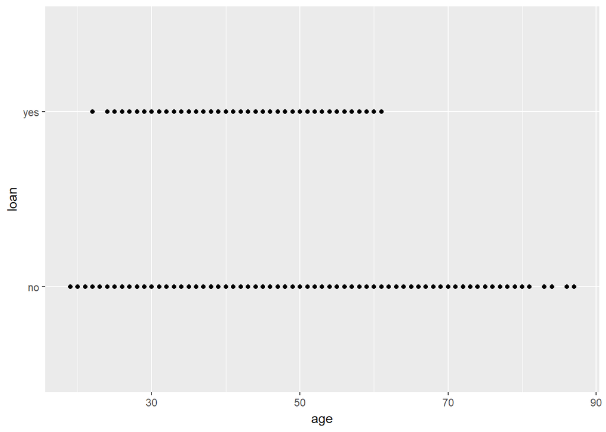

```r
ggplot(bank, aes(age, loan)) + geom_point()
```

# Finding 2

Count people in each age groups who default and don’t default people who are elder than 60 don’t default

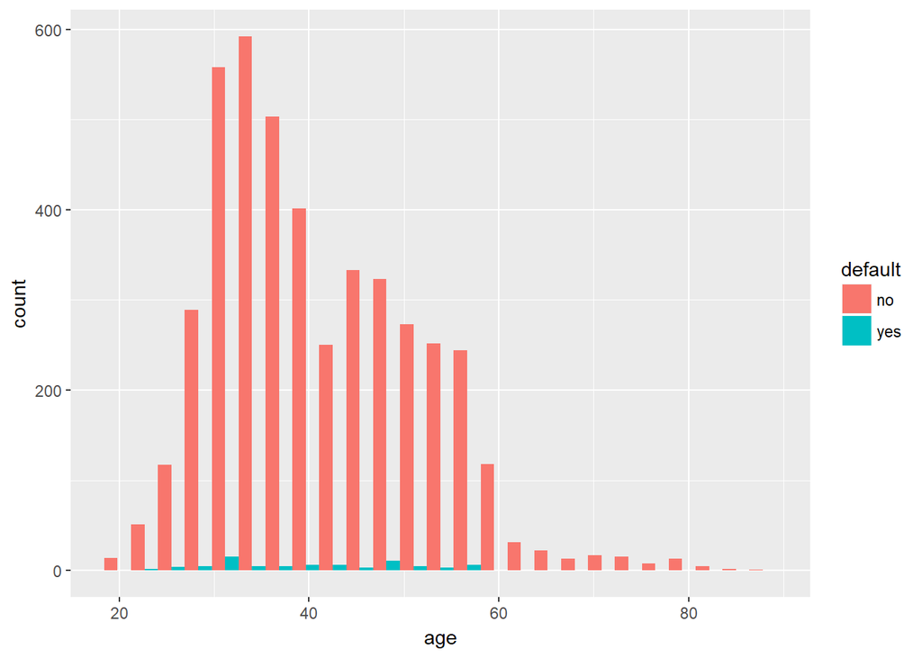

```r
ggplot(bank)+geom_histogram(mapping=aes(x=age,fill=default),bins = 25, position="dodge")
```

# Finding 3

Elder people tend to get lower education but Youngster people receive higher education.

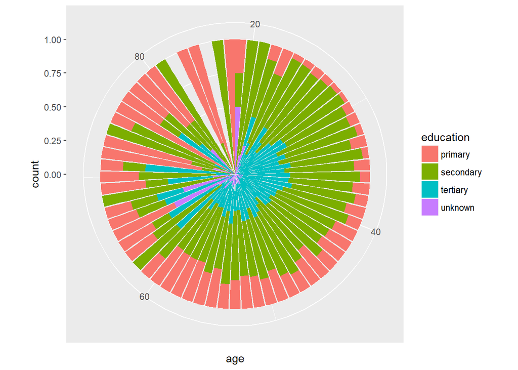

```r
ggplot(bank) +
geom_bar(mapping = aes(x = age, fill = education), position = "fill") +
coord_polar()
```

# Finding 4

Relationship between job and default:

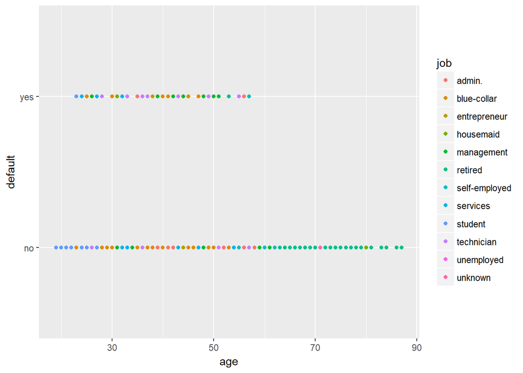

```r
ggplot(bank, aes(x = age, y = default, color = job)) +
geom_point() +theme(legend.position="right")
```

# Finding 5

Different duration depending on job and by contact group

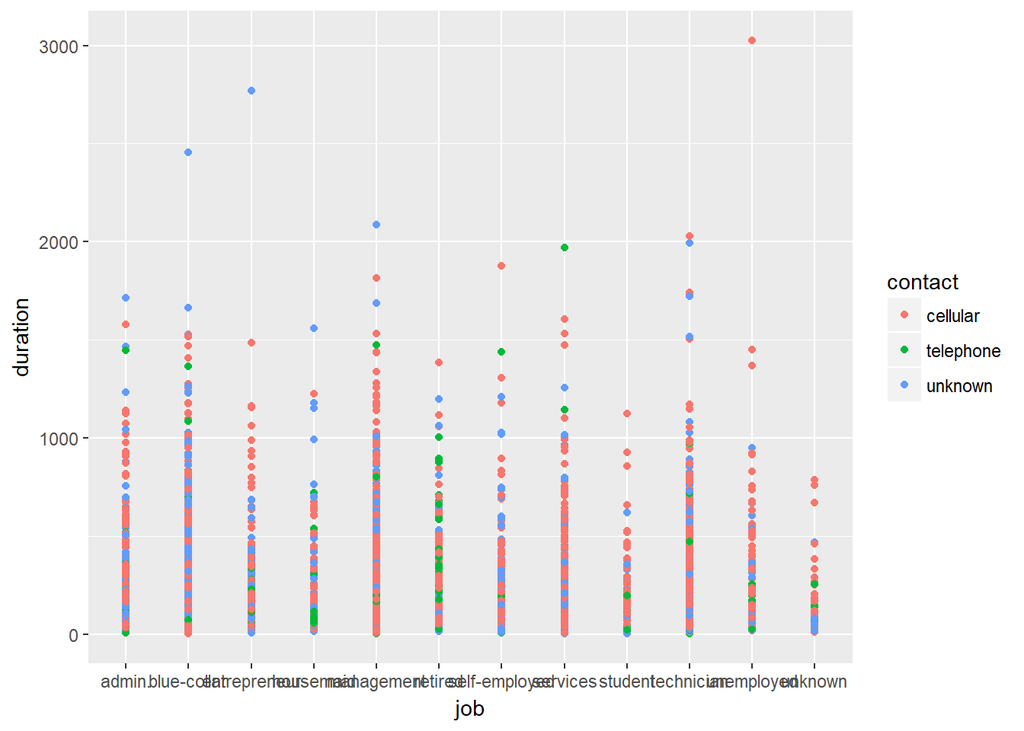

```r
ggplot(bank) + geom_point(aes(job, duration, color = contact))
```

# Finding 6

Relationship between hausing and balance in different age

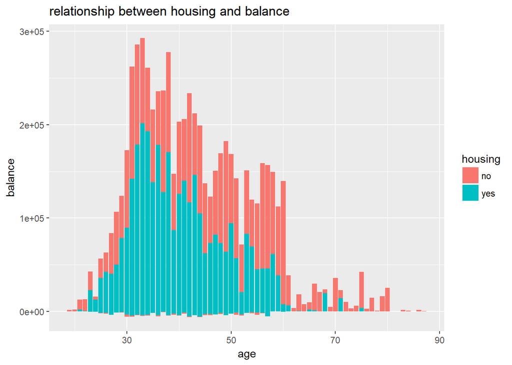

```r
ggplot(bank, aes(age,balance)) +
  geom_bar(aes(fill = housing), stat = "identity") +
  ggtitle("relationship between housing and balance")
```

# Finding 7

the relationship between job and education

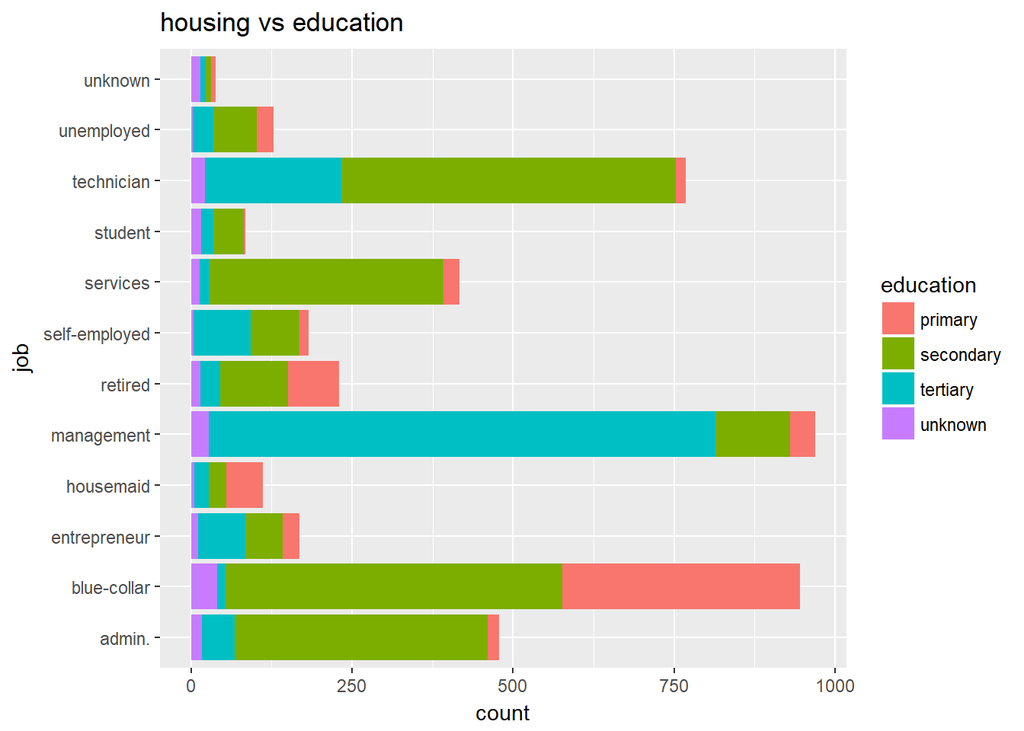

```r
ggplot(bank, mapping = aes(x = job, fill = education)) +
geom_bar() + coord_flip()+
ggtitle("housing vs education")
```

# Finding 8

marital status in different kind of education

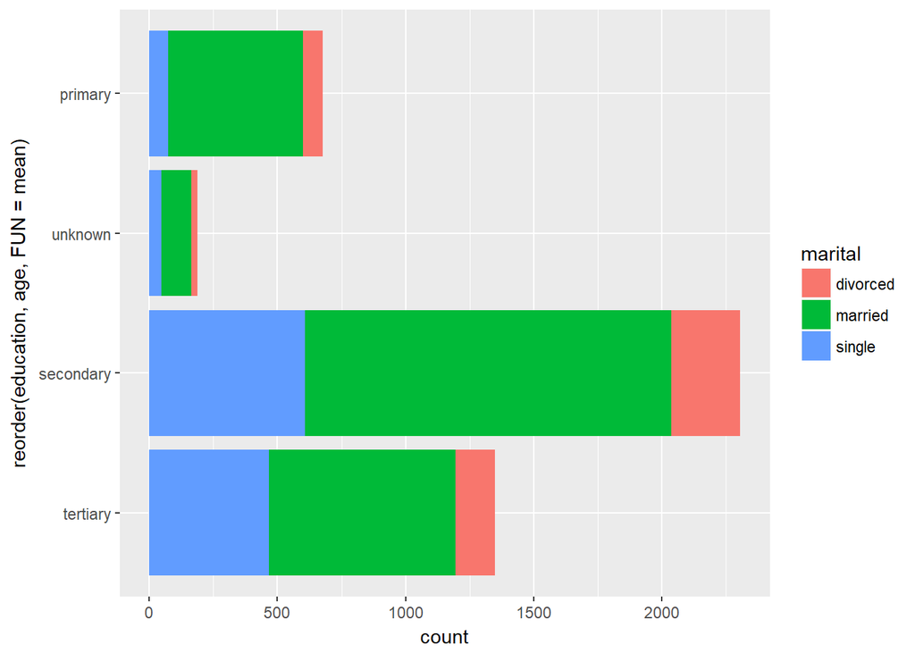

```r
ggplot(data = bank, mapping=aes(x=reorder(education, age, FUN=mean), fill=marital))+
  geom_bar()+coord_flip()
```

# Finding 9

Relationship between marital and age we can see that the married people have the widest age range

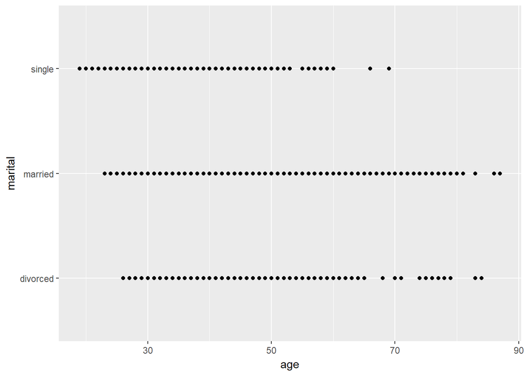

```r
ggplot(bank, aes(age, marital)) + geom_point()
```

# Finding 10

Plot of balance depending on age, grouped by marital and education

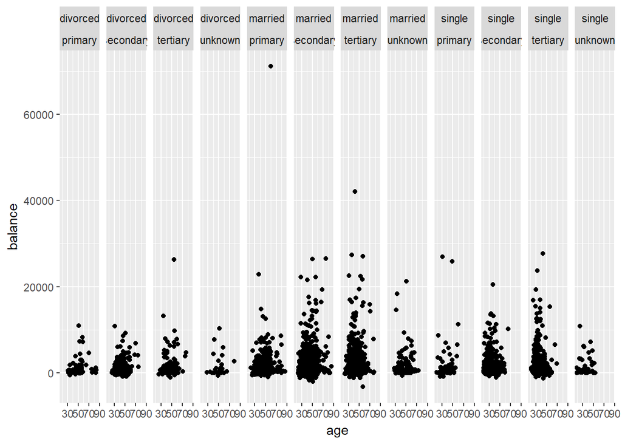

```r
ggplot(data = bank) +
geom_point(mapping = aes(age,balance)) +
facet_wrap(marital ~ education, nrow = 1)
```